# adding RVs

brian avery

September 16, 2018

```r
library(ggplot2)
set.seed(87349)
```

### adding UNIF

First, simulate several $UNIF(0,1)$ RVs, also sums of these RVs, and store in dataframe.

```r
uniforms <- data.frame(U=runif(100000), V=runif(100000), W=runif(100000),
                       X=runif(100000), Y=runif(100000), Z=runif(100000))
uniforms$two <- uniforms$U + uniforms$V
uniforms$three <- uniforms$U + uniforms$V + uniforms$W
uniforms$four <- uniforms$U + uniforms$V + uniforms$W + uniforms$X
uniforms$five <- uniforms$U + uniforms$V + uniforms$W + uniforms$X + uniforms$Y
head(uniforms)
```

```
##           U           V          W         X           Y          Z
## 1 0.2237303 0.212718492 0.21313572 0.8592435 0.230055725 0.39315550
## 2 0.6732303 0.049370517 0.09932315 0.5116051 0.323103104 0.51446665
## 3 0.1352415 0.004280132 0.06291041 0.2264902 0.005689052 0.61851831
## 4 0.8180958 0.846841856 0.58342319 0.5776902 0.170271991 0.04613788
## 5 0.4162543 0.663753846 0.88186666 0.1426889 0.240065767 0.08535646
## 6 0.5642494 0.099078418 0.60979669 0.2343633 0.838472871 0.17989737
##         two     three      four      five
## 1 0.4364488 0.6495845 1.5088279 1.7388837
## 2 0.7226008 0.8219240 1.3335291 1.6566322
## 3 0.1395216 0.2024320 0.4289222 0.4346113
## 4 1.6649377 2.2483608 2.8260510 2.9963230
## 5 1.0800081 1.9618748 2.1045637 2.3446294
## 6 0.6633279 1.2731245 1.5074878 2.3459607
```

**Each pair of graphs is:**  
Left side - histogram of RV Right side - density of simulated RV in blue, Normal RV with same mean and sd as simulated RV in orange.

single $UNIF(0,1)$

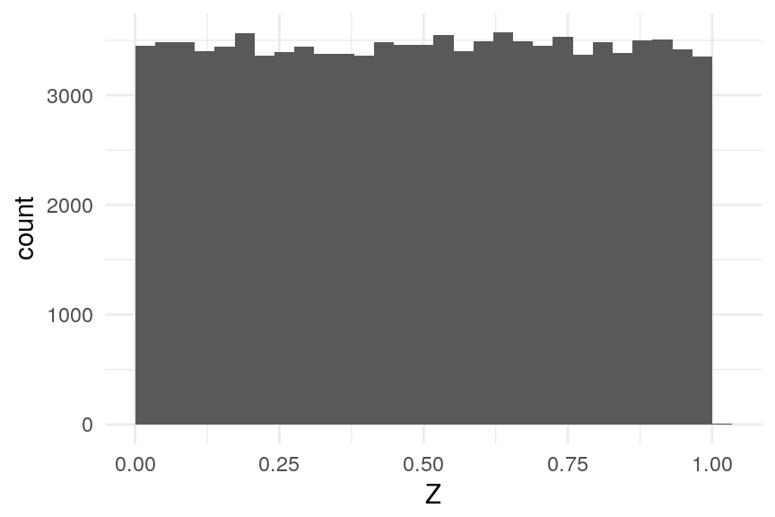

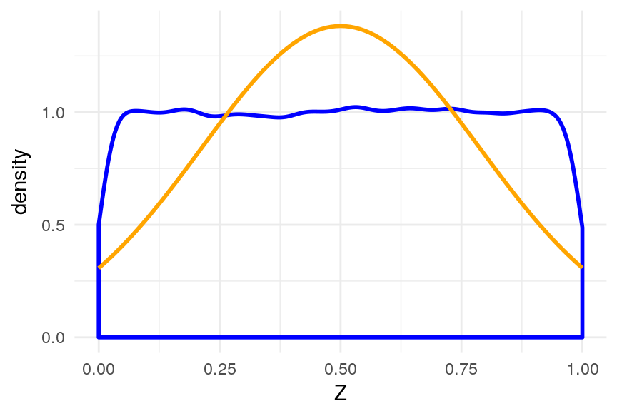

```r
ggplot(uniforms, aes(Z)) + geom_histogram(boundary=0) + theme_minimal()
ggplot(uniforms, aes(Z)) + geom_density(color="blue", size=1) +
  stat_function(fun=dnorm, args=list(mean=mean(uniforms$Z),
                                     sd=sd(uniforms$Z)), color="orange", size=1) +
  theme_minimal()
```

two $UNIF(0,1)$

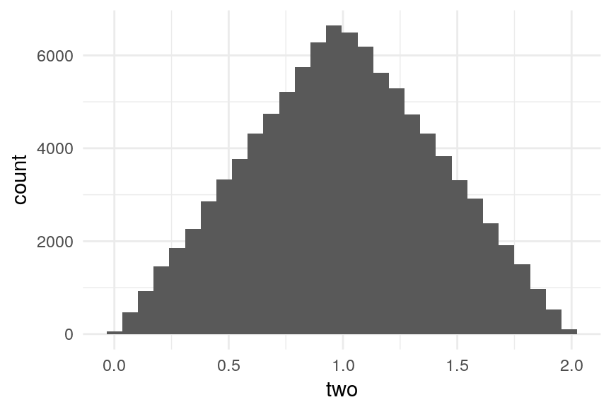

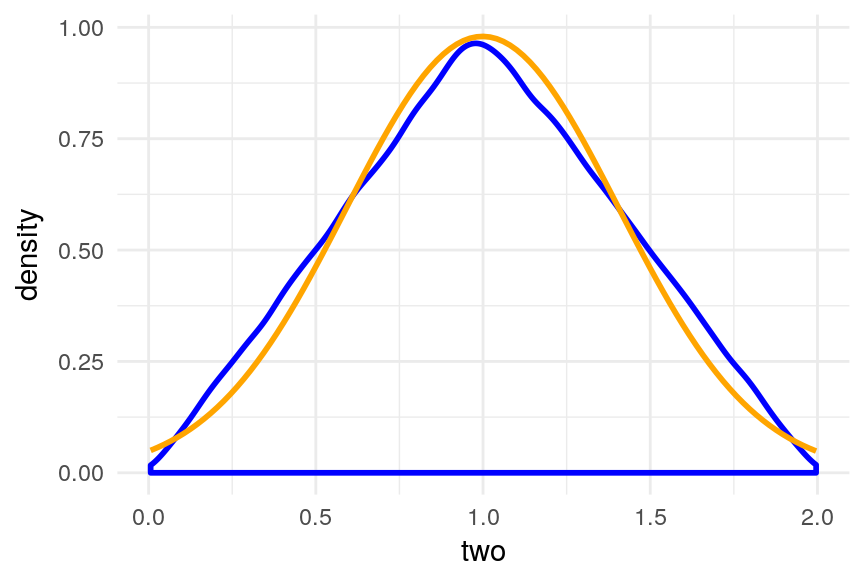

```r
ggplot(uniforms, aes(two)) + geom_histogram() + theme_minimal()
ggplot(uniforms, aes(two)) + geom_density(color="blue", size=1) +
  stat_function(fun=dnorm, args=list(mean=mean(uniforms$two),
                                     sd=sd(uniforms$two)), color="orange", size=1) +
  theme_minimal()
```

three $UNIF(0,1)$

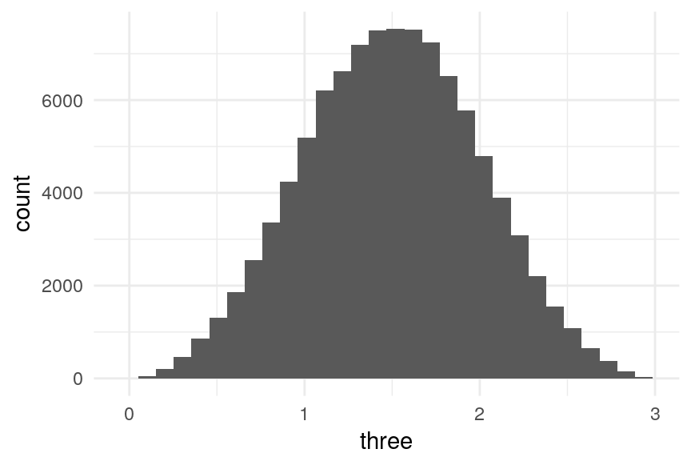

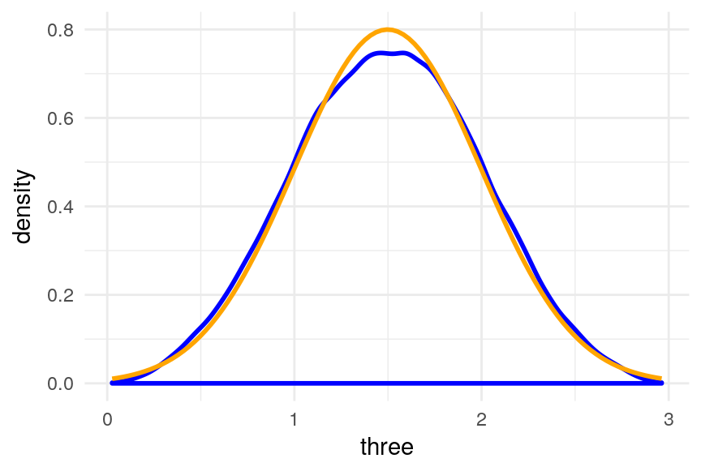

```r
ggplot(uniforms, aes(three)) + geom_histogram() + theme_minimal()
ggplot(uniforms, aes(three)) + geom_density(color="blue", size=1) +
  stat_function(fun=dnorm, args=list(mean=mean(uniforms$three),
                                     sd=sd(uniforms$three)), color="orange", size=1) +
  theme_minimal()
```

adding three $UNIF(0,1)$ doesn’t look as much like a parabola, as it does a Normal, at least by eye…

four $UNIF(0,1)$

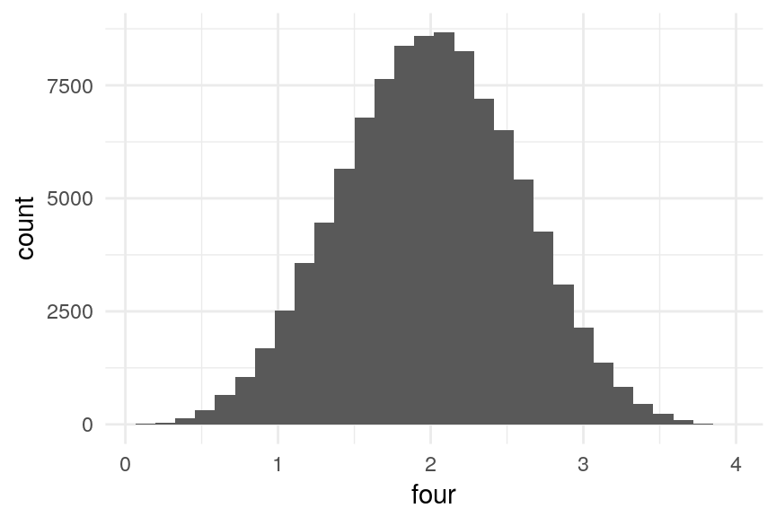

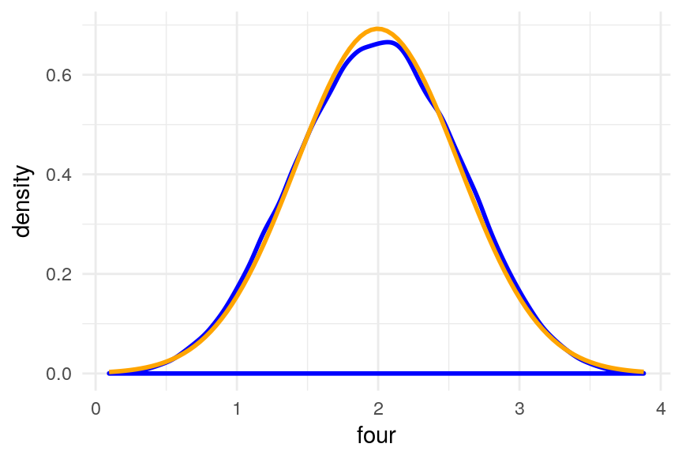

```r
ggplot(uniforms, aes(four)) + geom_histogram() + theme_minimal()
ggplot(uniforms, aes(four)) + geom_density(color="blue", size=1) +
  stat_function(fun=dnorm, args=list(mean=mean(uniforms$four),
                                     sd=sd(uniforms$four)), color="orange", size=1) +
  theme_minimal()
```

five $UNIF(0,1)$

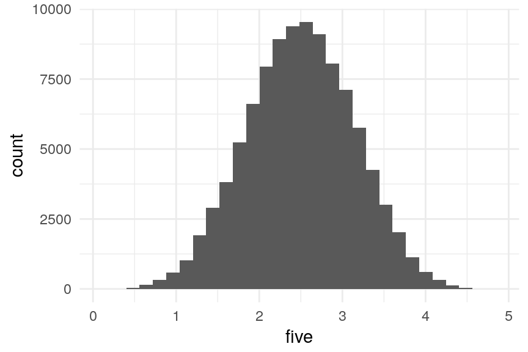

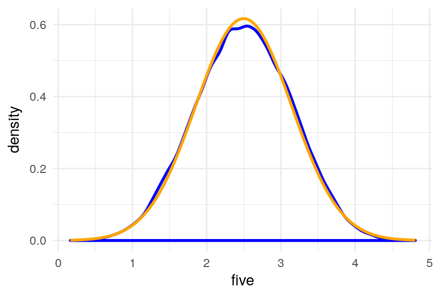

```r
ggplot(uniforms, aes(five)) + geom_histogram() + theme_minimal()
ggplot(uniforms, aes(five)) + geom_density(color="blue", size=1) +
  stat_function(fun=dnorm, args=list(mean=mean(uniforms$five),
                                     sd=sd(uniforms$five)), color="orange", size=1) +
  theme_minimal()
```

as you add more $UNIF(0,1)$ RVs together it looks more and more Normal.

### adding Normals

#### standard Normals (0,1)

First, simulate several $N(0,1)$ RVs, also sum of these RVs, and store in dataframe.

```r
norms <- data.frame(U=rnorm(100000), V=rnorm(100000), W=rnorm(100000),
                       X=rnorm(100000), Y=rnorm(100000), Z=rnorm(100000))
norms$two <- norms$U + norms$V
norms$three <- norms$U + norms$V + norms$W
norms$four <- norms$U + norms$V + norms$W + norms$X
norms$five <- norms$U + norms$V + norms$W + norms$X + norms$Y
head(norms)
```

```
##            U          V          W          X           Y            Z
## 1  0.9581680  0.1310740 -1.3868298 -2.8754473  1.00020538  0.006235532
## 2  0.5813510 -0.1671726  0.2535913 -1.8112824 -0.02783789 -0.157884604
## 3  1.1681468 -1.3054014  0.5745714  1.1506819  2.65099417  1.064256780
## 4  0.6596708 -0.1528759 -1.3677272 -0.8540412 -1.64139015  1.436712707
## 5 -0.7457130 -1.5081185 -1.4254729  0.1393246 -1.53245196 -2.052007159
## 6  0.2144402  0.3832123  1.5384686 -0.7112149  0.61895148  1.614482291
##          two      three      four      five
## 1  1.0892420 -0.2975879 -3.173035 -2.172830
## 2  0.4141783  0.6677696 -1.143513 -1.171351
## 3 -0.1372546  0.4373167  1.587999  4.238993
## 4  0.5067949 -0.8609323 -1.714974 -3.356364
## 5 -2.2538314 -3.6793043 -3.539980 -5.072432
## 6  0.5976525  2.1361211  1.424906  2.043858
```

**Each pair of graphs is:**  
Left side - histogram of RV Right side - density of simulated RV in blue, Normal RV with same mean and sd as simulated RV in orange.

one $N(0,1)$

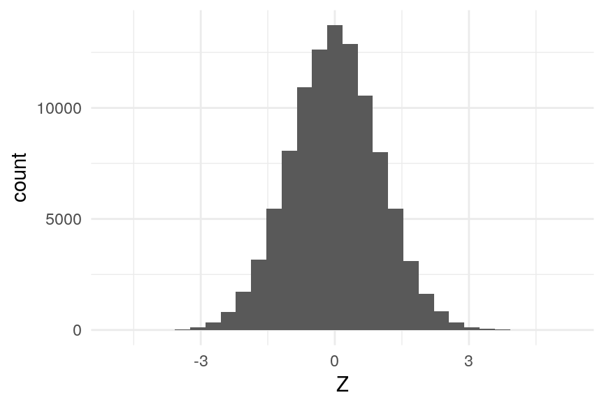

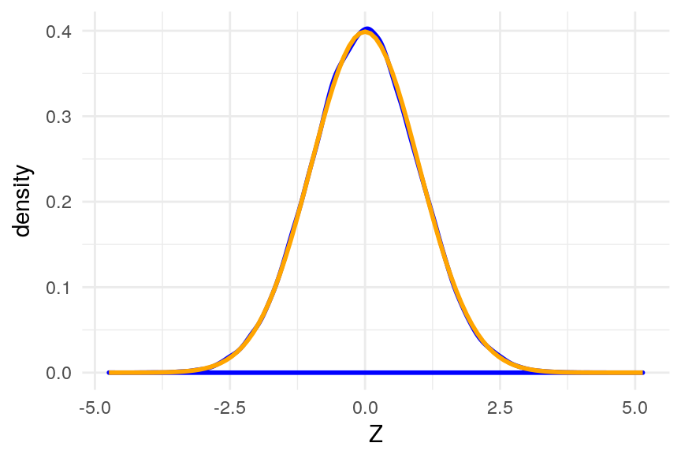

```r
ggplot(norms, aes(Z)) + geom_histogram() + theme_minimal()
ggplot(norms, aes(Z)) + geom_density(color="blue", size=1) +
  stat_function(fun=dnorm, args=list(mean=0,
                                     sd=1), color="orange", size=1) +
  theme_minimal()
```

two $N(0,1)$

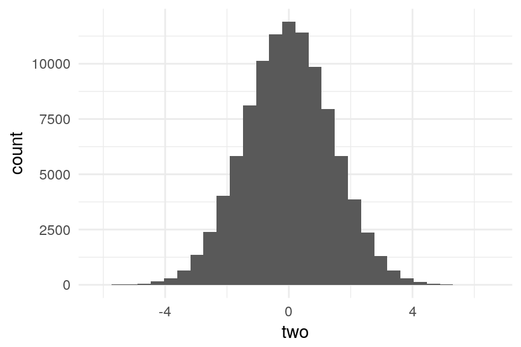

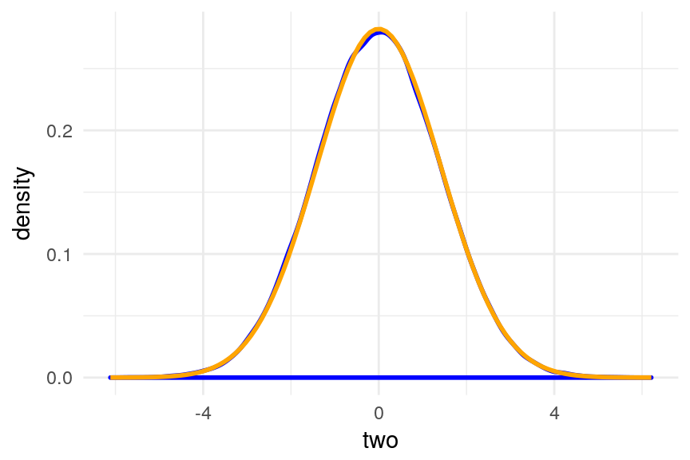

```r
ggplot(norms, aes(two)) + geom_histogram() + theme_minimal()
ggplot(norms, aes(two)) + geom_density(color="blue", size=1) +
  stat_function(fun=dnorm, args=list(mean=0,
                                     sd=sqrt(2)), color="orange", size=1) +
  theme_minimal()
```

three $N(0,1)$

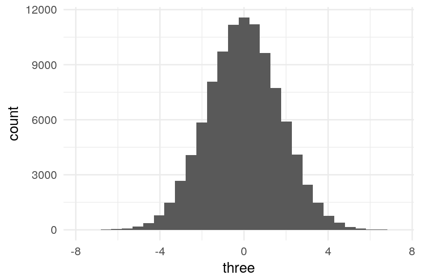

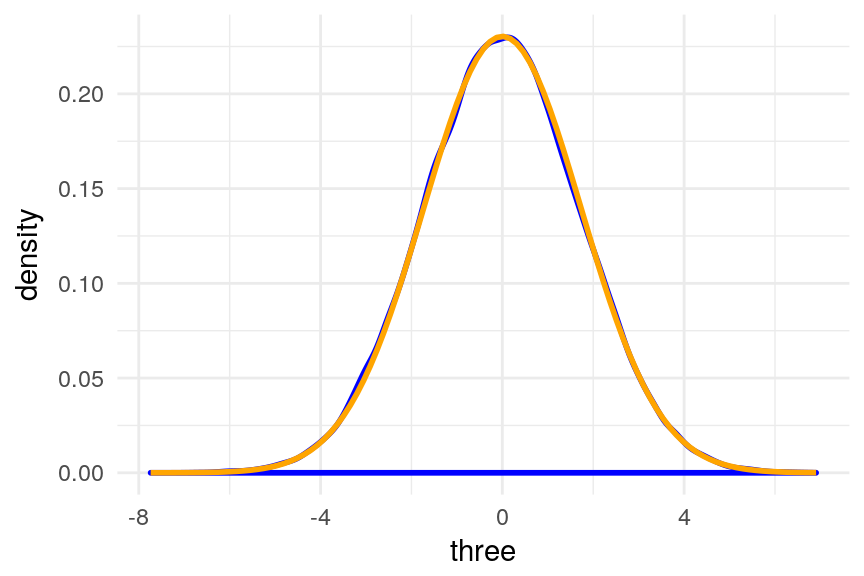

```r
ggplot(norms, aes(three)) + geom_histogram() + theme_minimal()
ggplot(norms, aes(three)) + geom_density(color="blue", size=1) +
  stat_function(fun=dnorm, args=list(mean=0,
                                     sd=sqrt(3)), color="orange", size=1) +
  theme_minimal()
```

four $N(0,1)$

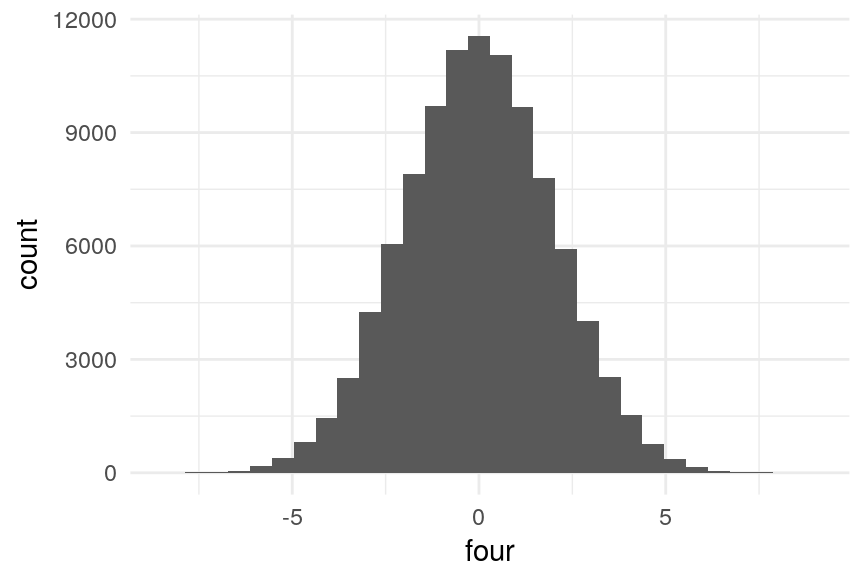

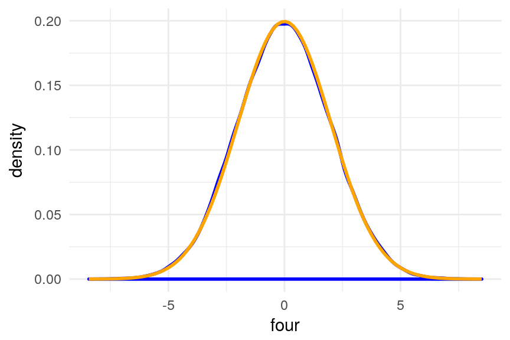

```r
ggplot(norms, aes(four)) + geom_histogram() + theme_minimal()
ggplot(norms, aes(four)) + geom_density(color="blue", size=1) +
  stat_function(fun=dnorm, args=list(mean=0,
                                     sd=sqrt(4)), color="orange", size=1) +
  theme_minimal()
```

five $N(0,1)$

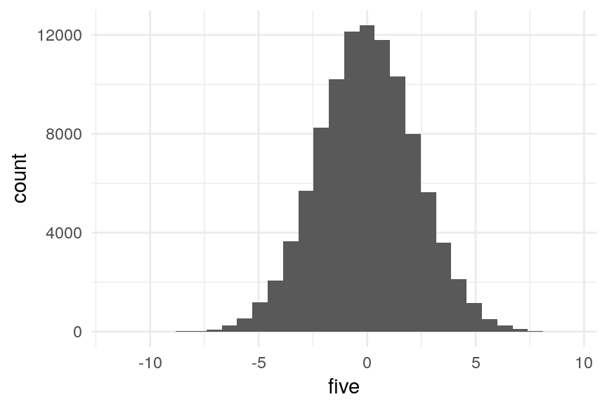

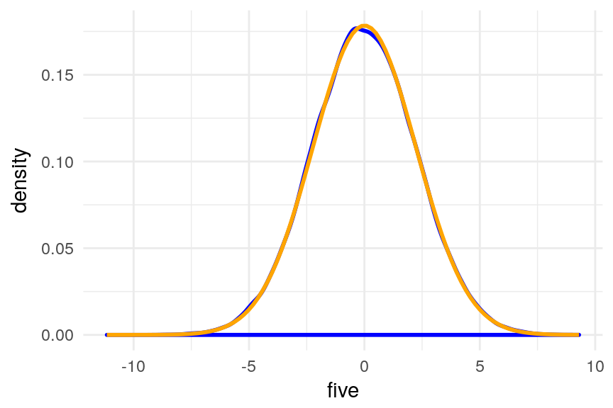

```r
ggplot(norms, aes(five)) + geom_histogram() + theme_minimal()
ggplot(norms, aes(five)) + geom_density(color="blue", size=1) +
  stat_function(fun=dnorm, args=list(mean=0,
                                     sd=sqrt(5)), color="orange", size=1) +
  theme_minimal()
```

1 $N(0,1)$ in grey, 2 $N(0,1)$ in green, 3 $N(0,1)$ in orange, 4 $N(0,1)$ in blue, 5 $N(0,1)$ in red all plotted on same axes.

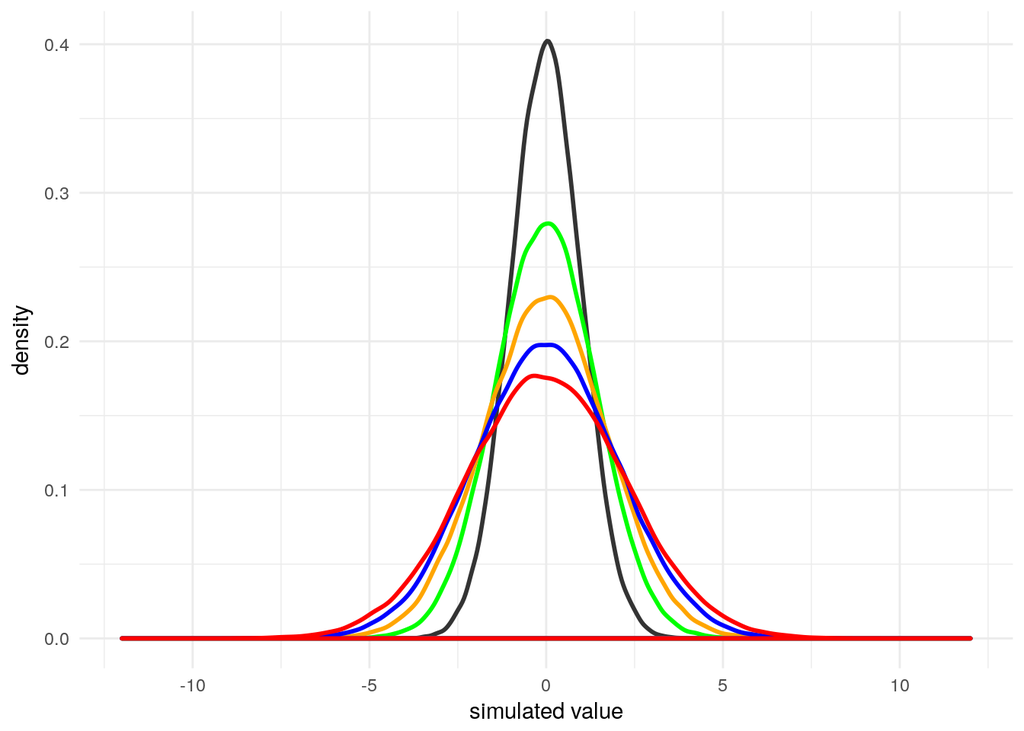

```r
ggplot(norms) + geom_density(aes(Z), color="grey20", size=1) +
  geom_density(aes(two), color="green", size=1) +
  geom_density(aes(three), color="orange", size=1) +
  geom_density(aes(four), color="blue", size=1) +
  geom_density(aes(five), color="red", size=1) +
  xlab("simulated value") + xlim(c(-12,12)) + theme_minimal()
```

#### Normals other than standard

simulate some different Normals:  
A is $N(1,1)$  
B is $N(0,2)$  
[*note*: I’m using $N( \mu, sd)$ since that is what R uses.]

also making sums of multiple iid A like RVs ($N(1,1)$) and sums of multiple iid B like RVs ($N(0,2)$).

```r
norms$A <- rnorm(100000, mean=1, sd=1)
norms$B <- rnorm(100000, mean=0, sd=2)
norms$Atwo <- norms$A + rnorm(100000, mean=1, sd=1)
norms$Athree <- norms$Atwo + rnorm(100000, mean=1, sd=1)
norms$Afour <- norms$Athree + rnorm(100000, mean=1, sd=1)
norms$Afive <- norms$Afour + rnorm(100000, mean=1, sd=1)
norms$Btwo <- norms$B + rnorm(100000, mean=0, sd=2)
norms$Bthree <- norms$Btwo + rnorm(100000, mean=0, sd=2)
norms$Bfour <- norms$Bthree + rnorm(100000, mean=0, sd=2)
norms$Bfive <- norms$Bfour + rnorm(100000, mean=0, sd=2)
head(norms[11:20])
```

```
##            A          B       Atwo     Athree    Afour    Afive       Btwo
## 1 -1.0438201 -4.8441826  0.8650604  1.3168871 2.318044 2.741057 -3.0955626
## 2  1.1912393  0.9785544  2.5942400  5.6255168 7.080638 9.948361 -0.1011114
## 3  1.9041271 -1.0798495  4.0626890  2.8878648 4.379048 5.087002 -5.1020909
## 4  0.5565502 -0.3527550  2.6218529  4.6465501 4.608646 4.213038 -2.8222264
## 5 -1.8627518  2.8063106 -0.4423007 -0.5511588 1.139664 1.968801  5.8245019
## 6  0.8872037 -5.0739639  1.5333508  4.2351763 5.117495 7.656440 -3.2865228
##      Bthree     Bfour     Bfive
## 1 -1.062202 -2.798807 -4.693949
## 2 -2.637423 -6.391763 -4.758033
## 3 -3.980746 -5.641978 -8.529242
## 4 -4.274471 -3.920905 -1.883908
## 5  9.955951  7.319866  6.562164
## 6 -5.537575 -5.019152 -4.418313
```

**Each pair of graphs is:**  
Left side - histogram of RV Right side - density of simulated RV in blue, Normal RV with same mean and sd as simulated RV in orange.

one A ($N(1,1)$)

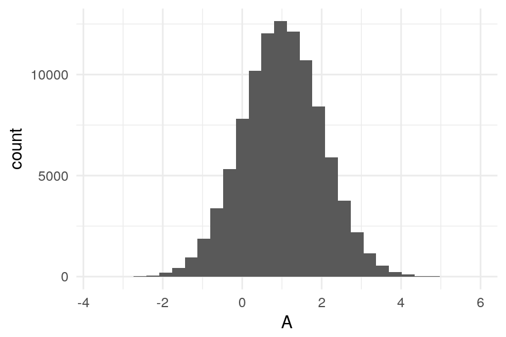

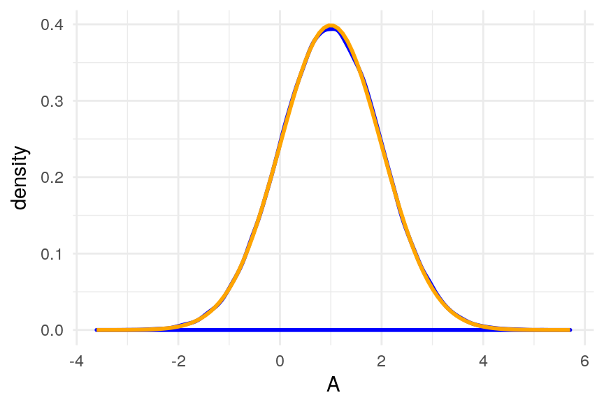

```r
ggplot(norms, aes(A)) + geom_histogram() + theme_minimal()
ggplot(norms, aes(A)) + geom_density(color="blue", size=1) +
  stat_function(fun=dnorm, args=list(mean=1,
                                     sd=1), color="orange", size=1) +
  theme_minimal()
```

five As ($N(1,1)$)

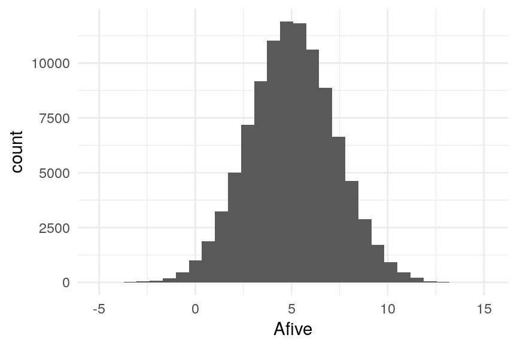

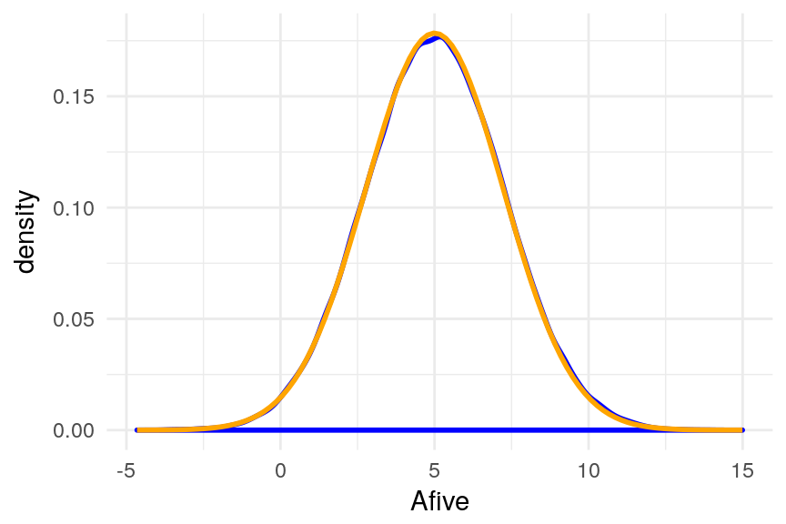

```r
ggplot(norms, aes(Afive)) + geom_histogram() + theme_minimal()
ggplot(norms, aes(Afive)) + geom_density(color="blue", size=1) +
  stat_function(fun=dnorm, args=list(mean=5,
                                     sd=sqrt(5)), color="orange", size=1) +
  theme_minimal()
```

one B ($N(0,2)$)

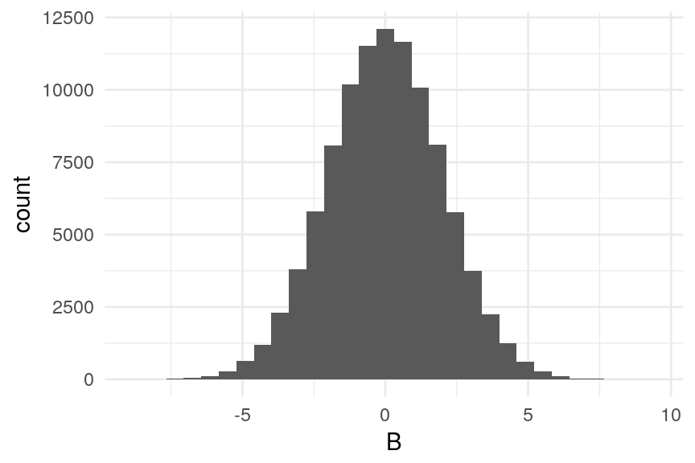

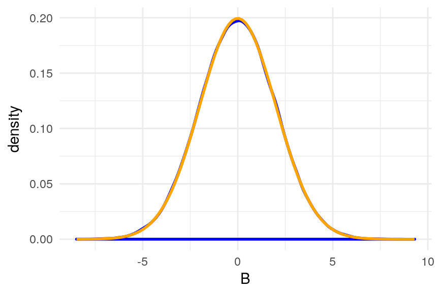

```r
ggplot(norms, aes(B)) + geom_histogram() + theme_minimal()
ggplot(norms, aes(B)) + geom_density(color="blue", size=1) +
  stat_function(fun=dnorm, args=list(mean=0,
                                     sd=2), color="orange", size=1) +
  theme_minimal()
```

five Bs ($N(0,2)$)

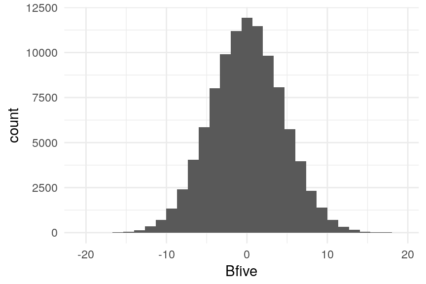

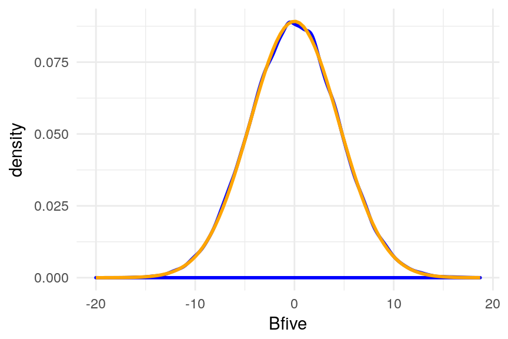

```r
ggplot(norms, aes(Bfive)) + geom_histogram() + theme_minimal()
ggplot(norms, aes(Bfive)) + geom_density(color="blue", size=1) +
  stat_function(fun=dnorm, args=list(mean=0,
                                     sd=sqrt(20)), color="orange", size=1) +
  theme_minimal()
```